# Data Visualization

Alex Rogers

```r
library(dplyr)
```

```r
library(ggplot2)
library(readr)

nc <- read_csv("https://docs.google.com/spreadsheets/d/e/2PACX-1vTm2WZwNBoQdZhMgot7urbtu8eG7tzAq-60ZJsQ_nupykCAcW0OXebVpHksPWyR4x8xJTVQ8KAulAFS/pub?gid=202410847&single=true&output=csv")
```

### Exercise 1

R is considering the variable habit to be a character type variable.

What is going on with my Y axis labels when I run this code?:

ggplot(data = nc, aes(x = weeks, y = weight)) + geom_point()

I am uploading this code to save it. When I generate the scatterplot my y axis labels are overlapping and messy. I am going to try starting over. I also noticed an error when I loaded the spreadsheet, that I was missing a library called curl so it was using url instead. I’m going to try to install the curl package.

I instaleld the curl package and the labels on the y axis are showing as I expected. I’m not sure if installing the package or restarting R fixed the problem. Next time I’ll save and just try relaunching R first.

I also noticed that before these changes the data frame had 743 entries, now it has 800 (still not the 1000 moderndive says there should be)

### Exercise 2

There is a positive relationship between length of pregnancy and birth weight of baby becasue as one increases so does the other.

### Exercise 3

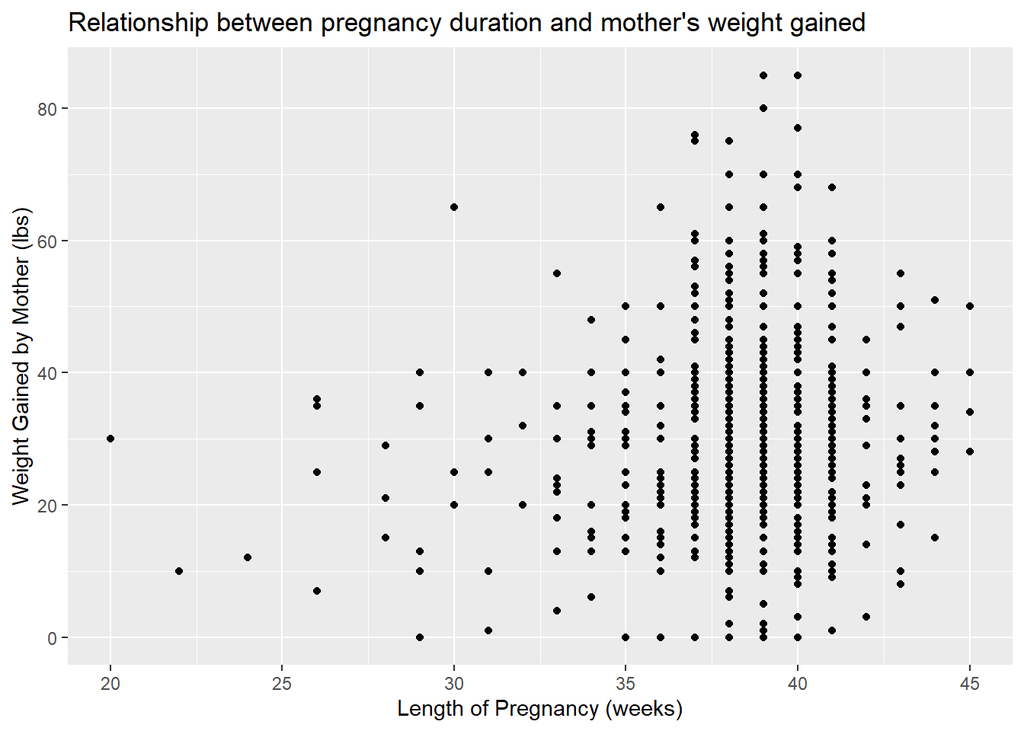

```r
ggplot(nc, aes(weeks, gained)) +
geom_point() +
labs(x = "Length of Pregnancy (weeks)", y = "Weight Gained by Mother (lbs)", title = "Relationship between pregnancy duration and mother's weight gained")
```

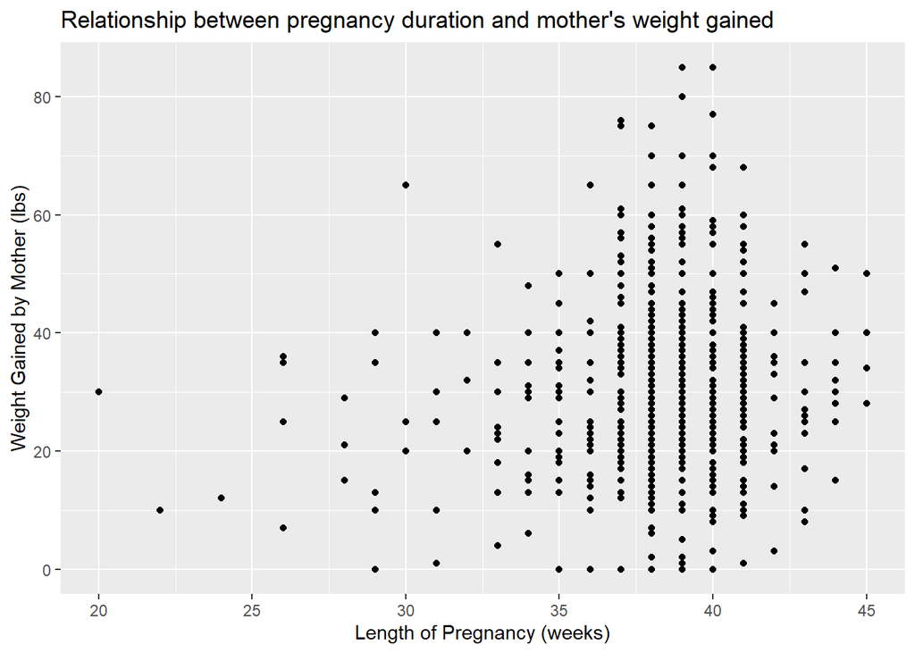

```r
ggplot(nc, aes(weeks, gained)) +
geom_point() +
labs(x = "Length of Pregnancy (weeks)", y = "Weight Gained by Mother (lbs)", title = "Relationship between pregnancy duration and mother's weight gained")
```

holy shit I did it.

jk I didn’t. now when I got to knit the markdown file I get the following error: “processing file: Rogers_HW2.Rmd Quitting from lines 37-44 (Rogers_HW2.Rmd) Error in ggplot(nc, aes(weeks, gained)) : could not find function”ggplot" Calls: … handle -> withCallingHandlers -> withVisible -> eval -> eval

Execution halted"

Same problem after deleting the code chunk, now the problem is coming from the following code chunk. I know I have ggplot loaded because I can run the code from the console. wtf is going on? it also runs the code when I run it from the markdown document, just can’t knit.

Alright I’m a goddamned genius. I didn’t understand that you needed to open the library in the rmarkdown document, I figured if you had loaded it in the console it would apply to the markdown file (which doesn’t really make sense in hindsight). I’ve loaded the necessary libraries and the data frame from the google sheet and it’s actually working.

### Exercise 4

A. Adding the argument color = premie made all data points with pregnancy length < ~37 blue

B. There are four? (maternal weight gain, pregnancy length, full term, premie)

C. The rough cutoff for a premie vs full term seems to be about 37 weeks

### Exercise 5

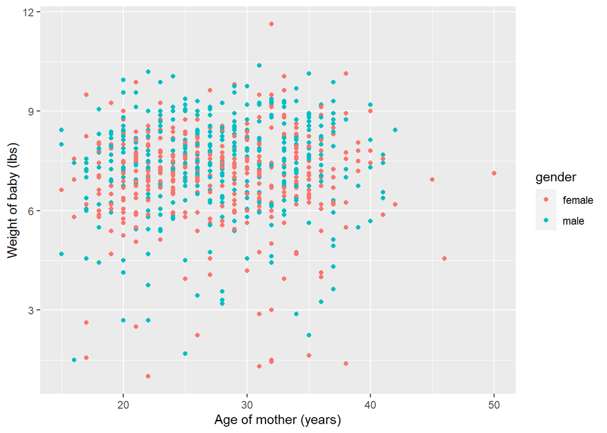

```r
ggplot(nc, aes(mage, weight, color = gender)) +
  geom_point() +
  labs(x = "Age of mother (years)", y = "Weight of baby (lbs)")
```

I don’t see a strong relationship between mother’s age and weight of baby. There seems to be a large cluster at about 7.5 lbs which spreads across mother ages.

### Histograms

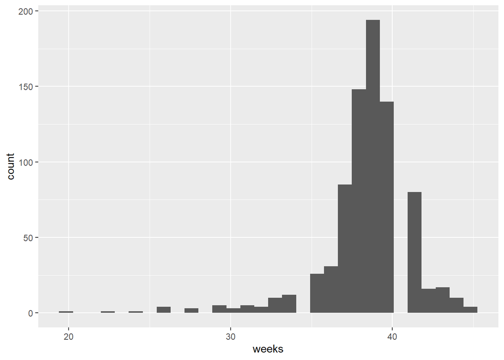

```r
ggplot(nc, aes(weeks)) +
  geom_histogram()
```

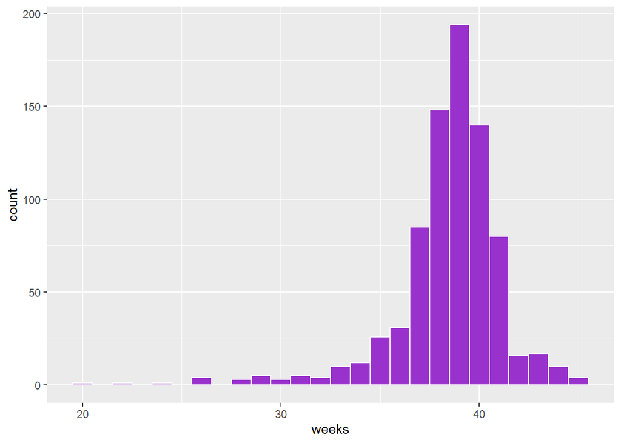

```r
ggplot(nc, aes(weeks)) +
  geom_histogram(binwidth = 1, color = "white", fill = "darkorchid")
```

### Exercise 6

A. I think that the y-axis “count” is counting the number of births recorded at a given number of weeks in the x-axis.

B. The average length of pregnancies in weeks seems to be ~39 or ~40

C. If we changed the binwidth to 100 there would be only one bin, that bin would contain 800 cases

### Exercise 7

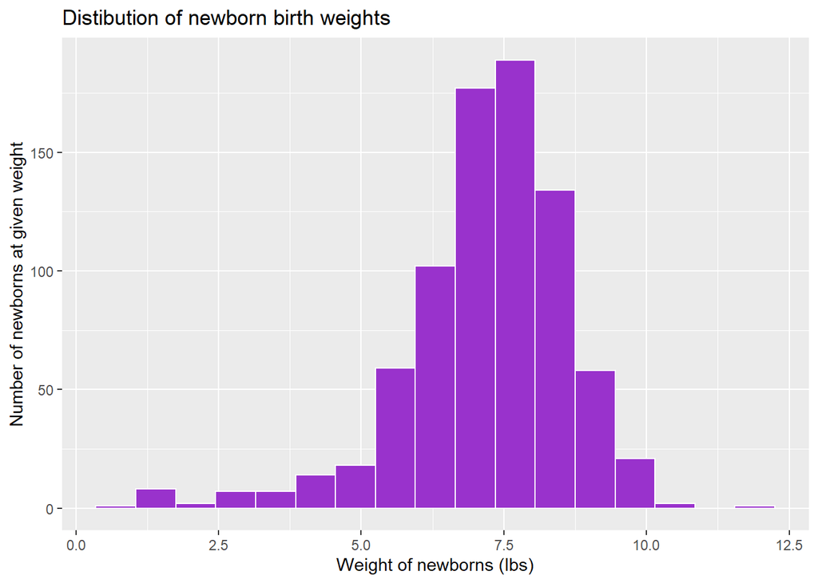

```r
ggplot(nc, aes(weight)) +
  geom_histogram(binwidth = 0.7, color = "white", fill = "darkorchid") +
  labs(x = "Weight of newborns (lbs)", y = "Number of newborns at given weight", title = "Distibution of newborn birth weights")
```

### Exercise 8

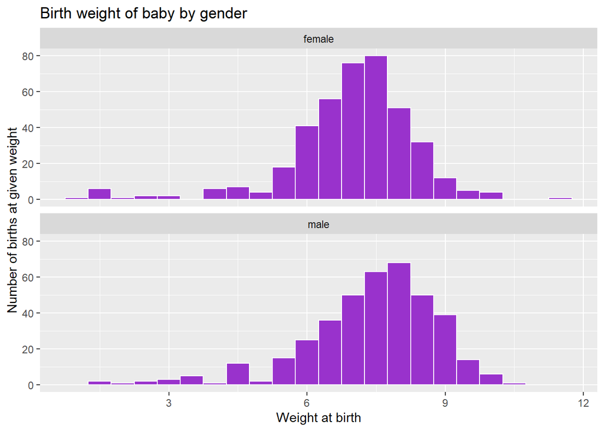

```r
ggplot(nc, aes(weight)) +
  geom_histogram(binwidth = 0.5, color = "white", fill = "darkorchid") +
  facet_wrap(~ gender, ncol = 1) +
  labs(x = "Weight at birth", y = "Number of births at given weight", title = "Birth weight of baby by gender")
```

### Exercise 9

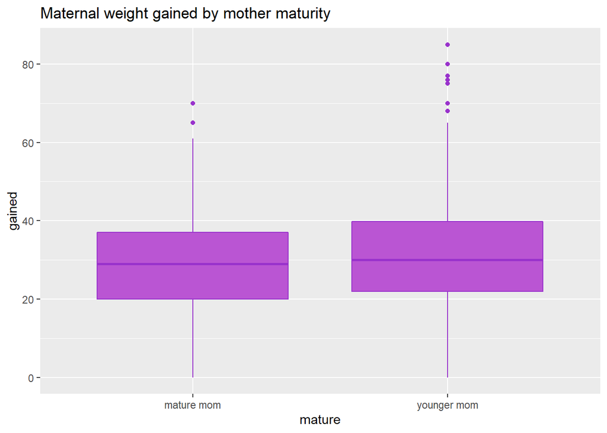

```r
ggplot(nc, aes(mature, gained)) +
  geom_boxplot(color = "darkorchid", fill = "mediumorchid") +
labs(title = "Maternal weight gained by mother maturity")
```

The median weight gain during pregnancy is larger for younger moms.

### Exercise 10

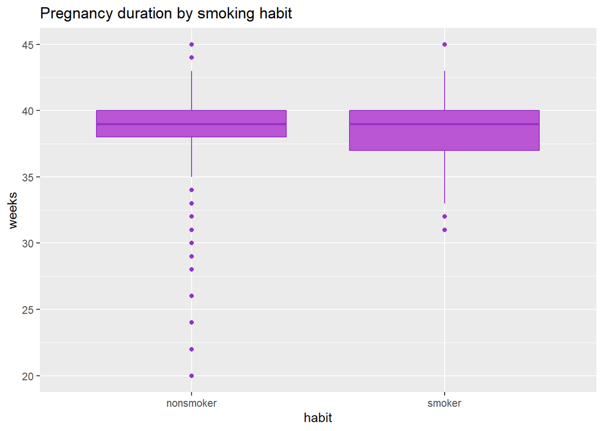

```r
ggplot(nc, aes(habit, weeks)) +
  geom_boxplot(color = "darkorchid", fill = "mediumorchid") +
  labs(title = "Pregnancy duration by smoking habit")
```

The duration of the pregnancy is more variable in the smoker group. I can tell this because the tail of the boxplot and the boxplot itself are longer than in the non-smoker group.

### Exercise 11

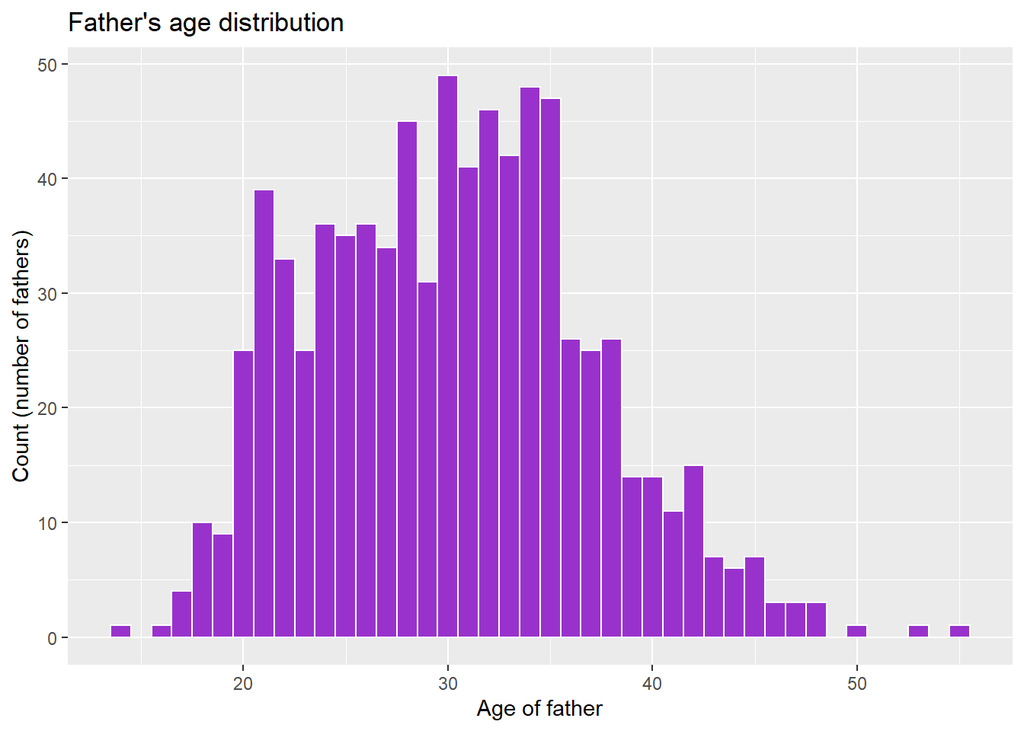

```r
ggplot(nc, aes(fage)) +
  geom_histogram(binwidth = 1, color = "white", fill = "darkorchid") +
labs(title = "Father's age distribution", x = "Age of father", y = "Count (number of fathers)")
```

These data seem to have a slight skew to the right.

### Exercise 12

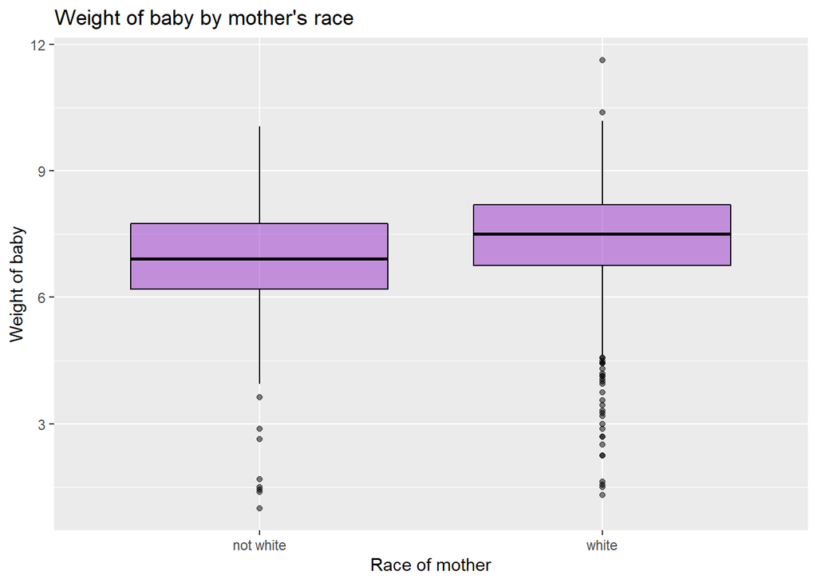

```r
ggplot(nc, aes(whitemom, weight)) +
geom_boxplot(color = "black", fill = "darkorchid", alpha = 0.5) +
labs(title = "Weight of baby by mother's race", x = "Race of mother", y = "Weight of baby")
```

I can tell that the media birth weight is higher when the mother is white because the middle line of the boxplot is higher (visually) for the white boxplot than the not white

### Exercise 13

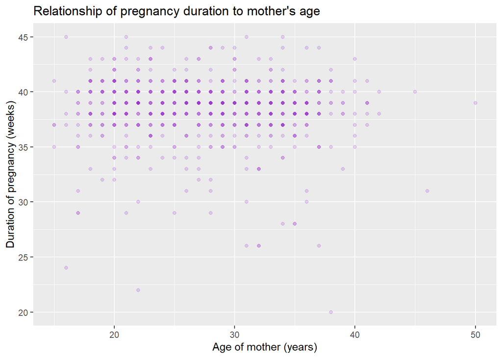

```r
ggplot(nc, aes(mage, weeks)) +
  geom_point(color = "darkorchid", alpha = 0.2) +
labs(title = "Relationship of pregnancy duration to mother's age", x = "Age of mother (years)", y = "Duration of pregnancy (weeks)")
```

It doesn’t appear that as the age of the mother increases the duration of the pregnancy decreases.